# **Dutch Product Price Analysis**

## 3. Descriptive Statistics

The following section focuses on the statistical methodologies used to understand the nature of the data and identify patterns within it. The aim is to use the insights generated to specify further investigations into price differences.

To begin, examine the descriptive statistics of the different product prices.

```python
dataset.groupby([dataset['website'], dataset['item']]).describe()
```

| website | item | price count | price mean | price std | price min | price 25% | price 50% | price 75% | price max |
| --- | --- | --- | --- | --- | --- | --- | --- | --- | --- |
| AH | bier | 372.0 | 10.036909 | 4.804548 | 0.30 | 6.8750 | 9.955 | 13.5200 | 22.76 |
|  | boter | 372.0 | 10.473871 | 4.845388 | 0.15 | 6.9425 | 10.390 | 13.6675 | 24.03 |
|  | brood | 372.0 | 9.996909 | 4.889011 | 0.03 | 6.7375 | 9.830 | 13.1750 | 26.71 |
|  | kaas | 372.0 | 10.108683 | 4.532393 | 0.02 | 7.2600 | 10.140 | 12.9750 | 23.57 |
|  | melk | 372.0 | 10.527151 | 4.977114 | 0.11 | 7.3050 | 10.230 | 13.5725 | 30.24 |
|  | rijst | 372.0 | 9.759892 | 4.877919 | 0.14 | 6.5475 | 9.295 | 12.8825 | 23.39 |
|  | shampoo | 372.0 | 9.701720 | 4.434210 | 0.04 | 6.6650 | 9.535 | 12.8925 | 22.50 |
|  | tandpasta | 372.0 | 10.490081 | 4.592223 | 0.11 | 7.3525 | 10.280 | 13.6175 | 28.40 |
|  | toiletpapier | 372.0 | 10.179462 | 4.975054 | 0.05 | 6.7025 | 10.155 | 13.6450 | 25.26 |
|  | waspoeder | 372.0 | 10.094274 | 4.942366 | 0.04 | 6.7075 | 9.980 | 13.4550 | 21.72 |
| Bonprix | badpak | 372.0 | 10.162177 | 5.810105 | 0.00 | 5.0700 | 10.215 | 15.1800 | 19.91 |
|  | jurk | 372.0 | 9.889382 | 5.721596 | 0.05 | 4.6475 | 10.010 | 14.3575 | 19.99 |
|  | overhemd | 372.0 | 10.279866 | 5.641259 | 0.09 | 5.5425 | 10.045 | 15.2675 | 19.98 |
|  | pyjama | 372.0 | 10.185860 | 5.694142 | 0.02 | 5.5250 | 10.050 | 15.2275 | 19.95 |
|  | rok | 372.0 | 9.982500 | 5.759994 | 0.02 | 5.2100 | 9.755 | 14.7600 | 19.98 |
|  | rugzak | 372.0 | 10.661505 | 5.487109 | 0.23 | 6.4150 | 11.155 | 15.2900 | 19.99 |
|  | slaapzak | 372.0 | 10.235242 | 5.737792 | 0.00 | 5.4150 | 10.440 | 15.2875 | 20.00 |
|  | spiegel | 372.0 | 10.080242 | 5.876740 | 0.08 | 5.0800 | 9.625 | 15.3825 | 19.95 |
|  | tafellaken | 372.0 | 10.104167 | 5.712087 | 0.04 | 5.0225 | 9.795 | 14.9075 | 19.99 |
|  | vloerkleed | 372.0 | 9.833011 | 5.719746 | 0.10 | 4.6750 | 9.855 | 14.7000 | 19.96 |
| Coolblue | grasmaaier | 372.0 | 36.397903 | 14.588670 | 1.03 | 26.8400 | 36.580 | 45.6525 | 86.68 |
|  | koelkast | 372.0 | 34.925645 | 14.204794 | 1.17 | 25.4250 | 34.170 | 45.4225 | 79.75 |
|  | laptop | 372.0 | 34.463925 | 15.297022 | 0.36 | 23.9500 | 34.750 | 44.1475 | 84.83 |
|  | loopband | 372.0 | 34.988817 | 14.814872 | 0.38 | 24.8175 | 35.855 | 45.3725 | 71.90 |
|  | magnetron | 372.0 | 34.650242 | 14.622001 | 0.78 | 25.0000 | 34.185 | 43.7375 | 75.61 |
|  | printer | 372.0 | 35.301613 | 14.502443 | 1.42 | 25.3300 | 35.040 | 45.4850 | 74.99 |
|  | steelstofzuiger | 372.0 | 34.335672 | 14.812585 | 0.73 | 24.8350 | 33.895 | 44.8000 | 74.63 |
|  | tondeuse | 372.0 | 35.081855 | 14.471116 | 1.25 | 25.2000 | 34.070 | 44.4275 | 81.58 |
|  | vaatwasser | 372.0 | 34.385780 | 15.410738 | 0.21 | 23.6700 | 33.920 | 45.3850 | 84.17 |
|  | wasmachine | 372.0 | 34.252419 | 14.581221 | 0.84 | 25.1025 | 34.795 | 42.9075 | 81.12 |
| Kruidvat | babyvoeding | 372.0 | 10.044220 | 5.862755 | 0.07 | 5.4550 | 9.785 | 15.4150 | 19.97 |
|  | douchegel | 372.0 | 10.400672 | 5.659698 | 0.03 | 5.5975 | 10.615 | 15.2725 | 19.98 |
|  | haarborstel | 372.0 | 10.062769 | 5.627118 | 0.04 | 4.8675 | 10.155 | 14.7850 | 19.91 |
|  | haarspeld | 372.0 | 10.281505 | 5.676836 | 0.13 | 5.4975 | 10.090 | 14.8225 | 19.97 |
|  | mascara | 372.0 | 10.036183 | 5.940321 | 0.06 | 4.9250 | 9.995 | 15.5825 | 19.96 |
|  | scheerapparaat | 372.0 | 10.386263 | 5.780597 | 0.16 | 5.3950 | 10.615 | 15.2100 | 19.95 |
|  | shampoo | 372.0 | 10.084247 | 5.978820 | 0.01 | 5.2225 | 9.935 | 15.3775 | 19.99 |
|  | toiletpapier | 372.0 | 9.914140 | 6.032613 | 0.09 | 4.4300 | 9.880 | 15.1325 | 19.96 |
|  | waspoeder | 372.0 | 10.355188 | 5.664762 | 0.11 | 5.6725 | 10.435 | 15.0875 | 19.88 |
|  | wasverzachter | 372.0 | 9.593629 | 5.711350 | 0.02 | 4.4100 | 9.350 | 14.1150 | 19.79 |
| Lidl | autostoel | 372.0 | 10.282473 | 4.691365 | 0.01 | 7.0175 | 10.280 | 13.5425 | 24.22 |
|  | badkamerkast | 372.0 | 10.178925 | 4.934339 | 0.03 | 6.6725 | 9.910 | 13.4125 | 23.44 |
|  | haardroger | 372.0 | 10.034812 | 4.769037 | 0.09 | 6.8050 | 10.080 | 13.0150 | 23.93 |
|  | koelkast | 372.0 | 10.177231 | 4.688803 | 0.11 | 7.0400 | 10.050 | 13.3275 | 23.92 |
|  | koptelefoon | 372.0 | 10.179032 | 4.946515 | 0.13 | 6.7050 | 10.030 | 13.3225 | 27.54 |
|  | ladekast | 372.0 | 10.173629 | 4.898529 | 0.08 | 6.6400 | 10.345 | 13.5100 | 27.35 |
|  | loopfiets | 372.0 | 10.279220 | 4.521176 | 0.04 | 7.2550 | 10.235 | 13.0775 | 22.18 |
|  | rugzak | 372.0 | 10.393360 | 4.640009 | 0.58 | 7.0925 | 10.500 | 13.4650 | 23.10 |
|  | slaapzak | 372.0 | 10.422392 | 4.896548 | 0.04 | 6.7925 | 10.725 | 13.9400 | 23.32 |
|  | vloerkleed | 372.0 | 10.115430 | 4.912830 | 0.10 | 6.7075 | 9.820 | 13.4700 | 28.23 |
| Mediamarkt | grasmaaier | 372.0 | 35.036129 | 13.905600 | 2.76 | 23.8775 | 35.370 | 45.2525 | 73.90 |
|  | koelkast | 372.0 | 36.024462 | 15.268357 | 0.49 | 26.3675 | 36.445 | 45.6475 | 89.54 |
|  | laptop | 372.0 | 35.258548 | 16.528527 | 1.33 | 23.6375 | 35.230 | 45.9400 | 88.13 |
|  | loopband | 372.0 | 34.748091 | 14.785125 | 2.81 | 24.1650 | 35.075 | 45.1150 | 82.49 |
|  | magnetron | 372.0 | 35.816183 | 15.679800 | 1.52 | 25.7300 | 35.935 | 45.2150 | 95.76 |
|  | printer | 372.0 | 35.865565 | 14.819318 | 0.45 | 25.4125 | 36.440 | 46.3550 | 73.43 |
|  | steelstofzuiger | 372.0 | 35.071022 | 15.490778 | 1.11 | 24.7950 | 34.985 | 44.8900 | 83.19 |
|  | tondeuse | 372.0 | 35.356747 | 14.708947 | 1.46 | 24.4125 | 35.325 | 44.9650 | 81.98 |
|  | vaatwasser | 372.0 | 35.694677 | 14.358997 | 0.60 | 25.2650 | 35.780 | 45.1100 | 75.94 |
|  | wasmachine | 372.0 | 34.378199 | 14.712262 | 0.98 | 22.9950 | 33.555 | 44.0125 | 89.45 |

A nice visualisation of the descriptive statistics can be seen obtained using boxplots. Here we can visually compare the distribution of prices for different items on each website.

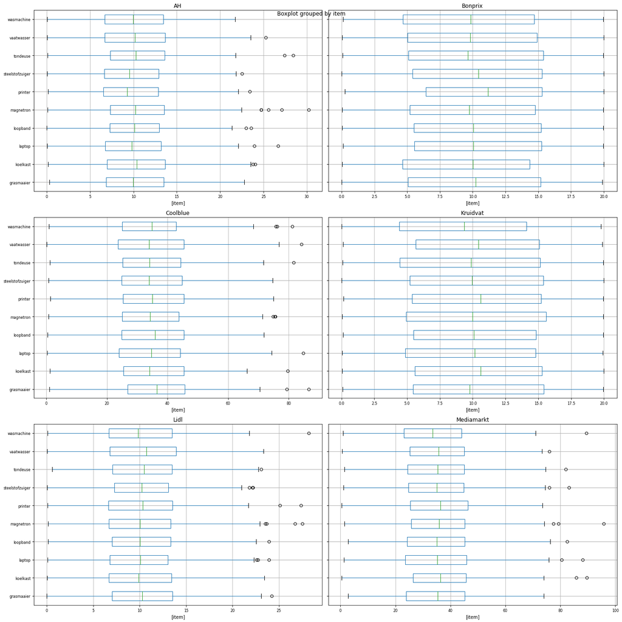

```python
ax = dataset.groupby(dataset['website']).boxplot(by = 'item', vert=False, figsize = (19,19), fontsize=8)
plt.tight_layout()
```

Every item has its own price range. To create a new variable for the range, calculated as max-min, once first needs to save the descriptive statistics as a manipulatable table and then make a few changes regarding indices and data types.

```python
summary_table = dataset.groupby([dataset['website'], dataset['item']]).describe().reset_index()
```

```python
print(summary_table.columns)
```

```
MultiIndex([('website',      ''),
            (   'item',      ''),
            (  'price', 'count'),
            (  'price',  'mean'),
            (  'price',   'std'),
            (  'price',   'min'),
            (  'price',   '25%'),
            (  'price',   '50%'),
            (  'price',   '75%'),
            (  'price',   'max')],
           )
```

As seen above, the columns have MultiIndex indices. It is more convenient to have single indices.

```python
summary_table.columns = ['_'.join(col) for col in summary_table.columns.values]
```

```python
print(summary_table.columns)
```

```
Index(['website_', 'item_', 'price_count', 'price_mean', 'price_std',
       'price_min', 'price_25%', 'price_50%', 'price_75%', 'price_max'],
      dtype='object')
```

```python
summary_table['price_max'] = summary_table['price_max'].astype(float)
summary_table['price_min'] = summary_table['price_min'].astype(float)
```

Now the variable 'range' can be calcuated and added.

```python
summary_table.insert(10,"range", (summary_table['price_max']-summary_table['price_min']))
```

```python
summary_table.head()
```

|  | website_ | item_ | price_count | price_mean | price_std | price_min | price_25% | price_50% | price_75% | price_max | range |
| --- | --- | --- | --- | --- | --- | --- | --- | --- | --- | --- | --- |
| 0 | AH | bier | 372.0 | 10.036909 | 4.804548 | 0.30 | 6.8750 | 9.955 | 13.5200 | 22.76 | 22.46 |
| 1 | AH | boter | 372.0 | 10.473871 | 4.845388 | 0.15 | 6.9425 | 10.390 | 13.6675 | 24.03 | 23.88 |
| 2 | AH | brood | 372.0 | 9.996909 | 4.889011 | 0.03 | 6.7375 | 9.830 | 13.1750 | 26.71 | 26.68 |
| 3 | AH | kaas | 372.0 | 10.108683 | 4.532393 | 0.02 | 7.2600 | 10.140 | 12.9750 | 23.57 | 23.55 |
| 4 | AH | melk | 372.0 | 10.527151 | 4.977114 | 0.11 | 7.3050 | 10.230 | 13.5725 | 30.24 | 30.13 |

It is interesting to separate the products with price ranges of zero, meaning their prices remain exactly constant over time, from the products whose price ranges are non-zero, meaning their prices fluctuate over time. First we count and identify the products with constant prices:

```python
constant_prices = summary_table
constant_prices = constant_prices.loc[constant_prices["range"] == 0]
len(constant_prices) # This counts the number of products
```

```
0
```

```python
constant_prices
```

|  | website_ | item_ | price_count | price_mean | price_std | price_min | price_25% | price_50% | price_75% | price_max | range |
| --- | --- | --- | --- | --- | --- | --- | --- | --- | --- | --- | --- |

Now we examine the products with fluctuating prices over time:

```python
changing_prices = summary_table
changing_prices = changing_prices.loc[changing_prices["range"] != 0]
len(changing_prices)
```

```
60
```

```python
changing_prices
```

|  | website_ | item_ | price_count | price_mean | price_std | price_min | price_25% | price_50% | price_75% | price_max | range |
| --- | --- | --- | --- | --- | --- | --- | --- | --- | --- | --- | --- |
| 0 | AH | bier | 372.0 | 10.036909 | 4.804548 | 0.30 | 6.8750 | 9.955 | 13.5200 | 22.76 | 22.46 |
| 1 | AH | boter | 372.0 | 10.473871 | 4.845388 | 0.15 | 6.9425 | 10.390 | 13.6675 | 24.03 | 23.88 |
| 2 | AH | brood | 372.0 | 9.996909 | 4.889011 | 0.03 | 6.7375 | 9.830 | 13.1750 | 26.71 | 26.68 |
| 3 | AH | kaas | 372.0 | 10.108683 | 4.532393 | 0.02 | 7.2600 | 10.140 | 12.9750 | 23.57 | 23.55 |
| 4 | AH | melk | 372.0 | 10.527151 | 4.977114 | 0.11 | 7.3050 | 10.230 | 13.5725 | 30.24 | 30.13 |
| 5 | AH | rijst | 372.0 | 9.759892 | 4.877919 | 0.14 | 6.5475 | 9.295 | 12.8825 | 23.39 | 23.25 |
| 6 | AH | shampoo | 372.0 | 9.701720 | 4.434210 | 0.04 | 6.6650 | 9.535 | 12.8925 | 22.50 | 22.46 |
| 7 | AH | tandpasta | 372.0 | 10.490081 | 4.592223 | 0.11 | 7.3525 | 10.280 | 13.6175 | 28.40 | 28.29 |
| 8 | AH | toiletpapier | 372.0 | 10.179462 | 4.975054 | 0.05 | 6.7025 | 10.155 | 13.6450 | 25.26 | 25.21 |
| 9 | AH | waspoeder | 372.0 | 10.094274 | 4.942366 | 0.04 | 6.7075 | 9.980 | 13.4550 | 21.72 | 21.68 |
| 10 | Bonprix | badpak | 372.0 | 10.162177 | 5.810105 | 0.00 | 5.0700 | 10.215 | 15.1800 | 19.91 | 19.91 |
| 11 | Bonprix | jurk | 372.0 | 9.889382 | 5.721596 | 0.05 | 4.6475 | 10.010 | 14.3575 | 19.99 | 19.94 |
| 12 | Bonprix | overhemd | 372.0 | 10.279866 | 5.641259 | 0.09 | 5.5425 | 10.045 | 15.2675 | 19.98 | 19.89 |
| 13 | Bonprix | pyjama | 372.0 | 10.185860 | 5.694142 | 0.02 | 5.5250 | 10.050 | 15.2275 | 19.95 | 19.93 |
| 14 | Bonprix | rok | 372.0 | 9.982500 | 5.759994 | 0.02 | 5.2100 | 9.755 | 14.7600 | 19.98 | 19.96 |
| 15 | Bonprix | rugzak | 372.0 | 10.661505 | 5.487109 | 0.23 | 6.4150 | 11.155 | 15.2900 | 19.99 | 19.76 |
| 16 | Bonprix | slaapzak | 372.0 | 10.235242 | 5.737792 | 0.00 | 5.4150 | 10.440 | 15.2875 | 20.00 | 20.00 |
| 17 | Bonprix | spiegel | 372.0 | 10.080242 | 5.876740 | 0.08 | 5.0800 | 9.625 | 15.3825 | 19.95 | 19.87 |
| 18 | Bonprix | tafellaken | 372.0 | 10.104167 | 5.712087 | 0.04 | 5.0225 | 9.795 | 14.9075 | 19.99 | 19.95 |
| 19 | Bonprix | vloerkleed | 372.0 | 9.833011 | 5.719746 | 0.10 | 4.6750 | 9.855 | 14.7000 | 19.96 | 19.86 |
| 20 | Coolblue | grasmaaier | 372.0 | 36.397903 | 14.588670 | 1.03 | 26.8400 | 36.580 | 45.6525 | 86.68 | 85.65 |
| 21 | Coolblue | koelkast | 372.0 | 34.925645 | 14.204794 | 1.17 | 25.4250 | 34.170 | 45.4225 | 79.75 | 78.58 |
| 22 | Coolblue | laptop | 372.0 | 34.463925 | 15.297022 | 0.36 | 23.9500 | 34.750 | 44.1475 | 84.83 | 84.47 |
| 23 | Coolblue | loopband | 372.0 | 34.988817 | 14.814872 | 0.38 | 24.8175 | 35.855 | 45.3725 | 71.90 | 71.52 |
| 24 | Coolblue | magnetron | 372.0 | 34.650242 | 14.622001 | 0.78 | 25.0000 | 34.185 | 43.7375 | 75.61 | 74.83 |
| 25 | Coolblue | printer | 372.0 | 35.301613 | 14.502443 | 1.42 | 25.3300 | 35.040 | 45.4850 | 74.99 | 73.57 |
| 26 | Coolblue | steelstofzuiger | 372.0 | 34.335672 | 14.812585 | 0.73 | 24.8350 | 33.895 | 44.8000 | 74.63 | 73.90 |
| 27 | Coolblue | tondeuse | 372.0 | 35.081855 | 14.471116 | 1.25 | 25.2000 | 34.070 | 44.4275 | 81.58 | 80.33 |
| 28 | Coolblue | vaatwasser | 372.0 | 34.385780 | 15.410738 | 0.21 | 23.6700 | 33.920 | 45.3850 | 84.17 | 83.96 |
| 29 | Coolblue | wasmachine | 372.0 | 34.252419 | 14.581221 | 0.84 | 25.1025 | 34.795 | 42.9075 | 81.12 | 80.28 |
| 30 | Kruidvat | babyvoeding | 372.0 | 10.044220 | 5.862755 | 0.07 | 5.4550 | 9.785 | 15.4150 | 19.97 | 19.90 |
| 31 | Kruidvat | douchegel | 372.0 | 10.400672 | 5.659698 | 0.03 | 5.5975 | 10.615 | 15.2725 | 19.98 | 19.95 |
| 32 | Kruidvat | haarborstel | 372.0 | 10.062769 | 5.627118 | 0.04 | 4.8675 | 10.155 | 14.7850 | 19.91 | 19.87 |
| 33 | Kruidvat | haarspeld | 372.0 | 10.281505 | 5.676836 | 0.13 | 5.4975 | 10.090 | 14.8225 | 19.97 | 19.84 |
| 34 | Kruidvat | mascara | 372.0 | 10.036183 | 5.940321 | 0.06 | 4.9250 | 9.995 | 15.5825 | 19.96 | 19.90 |
| 35 | Kruidvat | scheerapparaat | 372.0 | 10.386263 | 5.780597 | 0.16 | 5.3950 | 10.615 | 15.2100 | 19.95 | 19.79 |
| 36 | Kruidvat | shampoo | 372.0 | 10.084247 | 5.978820 | 0.01 | 5.2225 | 9.935 | 15.3775 | 19.99 | 19.98 |
| 37 | Kruidvat | toiletpapier | 372.0 | 9.914140 | 6.032613 | 0.09 | 4.4300 | 9.880 | 15.1325 | 19.96 | 19.87 |
| 38 | Kruidvat | waspoeder | 372.0 | 10.355188 | 5.664762 | 0.11 | 5.6725 | 10.435 | 15.0875 | 19.88 | 19.77 |
| 39 | Kruidvat | wasverzachter | 372.0 | 9.593629 | 5.711350 | 0.02 | 4.4100 | 9.350 | 14.1150 | 19.79 | 19.77 |
| 40 | Lidl | autostoel | 372.0 | 10.282473 | 4.691365 | 0.01 | 7.0175 | 10.280 | 13.5425 | 24.22 | 24.21 |
| 41 | Lidl | badkamerkast | 372.0 | 10.178925 | 4.934339 | 0.03 | 6.6725 | 9.910 | 13.4125 | 23.44 | 23.41 |
| 42 | Lidl | haardroger | 372.0 | 10.034812 | 4.769037 | 0.09 | 6.8050 | 10.080 | 13.0150 | 23.93 | 23.84 |
| 43 | Lidl | koelkast | 372.0 | 10.177231 | 4.688803 | 0.11 | 7.0400 | 10.050 | 13.3275 | 23.92 | 23.81 |
| 44 | Lidl | koptelefoon | 372.0 | 10.179032 | 4.946515 | 0.13 | 6.7050 | 10.030 | 13.3225 | 27.54 | 27.41 |
| 45 | Lidl | ladekast | 372.0 | 10.173629 | 4.898529 | 0.08 | 6.6400 | 10.345 | 13.5100 | 27.35 | 27.27 |
| 46 | Lidl | loopfiets | 372.0 | 10.279220 | 4.521176 | 0.04 | 7.2550 | 10.235 | 13.0775 | 22.18 | 22.14 |
| 47 | Lidl | rugzak | 372.0 | 10.393360 | 4.640009 | 0.58 | 7.0925 | 10.500 | 13.4650 | 23.10 | 22.52 |
| 48 | Lidl | slaapzak | 372.0 | 10.422392 | 4.896548 | 0.04 | 6.7925 | 10.725 | 13.9400 | 23.32 | 23.28 |
| 49 | Lidl | vloerkleed | 372.0 | 10.115430 | 4.912830 | 0.10 | 6.7075 | 9.820 | 13.4700 | 28.23 | 28.13 |
| 50 | Mediamarkt | grasmaaier | 372.0 | 35.036129 | 13.905600 | 2.76 | 23.8775 | 35.370 | 45.2525 | 73.90 | 71.14 |
| 51 | Mediamarkt | koelkast | 372.0 | 36.024462 | 15.268357 | 0.49 | 26.3675 | 36.445 | 45.6475 | 89.54 | 89.05 |
| 52 | Mediamarkt | laptop | 372.0 | 35.258548 | 16.528527 | 1.33 | 23.6375 | 35.230 | 45.9400 | 88.13 | 86.80 |
| 53 | Mediamarkt | loopband | 372.0 | 34.748091 | 14.785125 | 2.81 | 24.1650 | 35.075 | 45.1150 | 82.49 | 79.68 |
| 54 | Mediamarkt | magnetron | 372.0 | 35.816183 | 15.679800 | 1.52 | 25.7300 | 35.935 | 45.2150 | 95.76 | 94.24 |
| 55 | Mediamarkt | printer | 372.0 | 35.865565 | 14.819318 | 0.45 | 25.4125 | 36.440 | 46.3550 | 73.43 | 72.98 |
| 56 | Mediamarkt | steelstofzuiger | 372.0 | 35.071022 | 15.490778 | 1.11 | 24.7950 | 34.985 | 44.8900 | 83.19 | 82.08 |
| 57 | Mediamarkt | tondeuse | 372.0 | 35.356747 | 14.708947 | 1.46 | 24.4125 | 35.325 | 44.9650 | 81.98 | 80.52 |
| 58 | Mediamarkt | vaatwasser | 372.0 | 35.694677 | 14.358997 | 0.60 | 25.2650 | 35.780 | 45.1100 | 75.94 | 75.34 |
| 59 | Mediamarkt | wasmachine | 372.0 | 34.378199 | 14.712262 | 0.98 | 22.9950 | 33.555 | 44.0125 | 89.45 | 88.47 |

To obtain a comparable visualization for each product's price range, we can create a bar graph.

```python
changing_prices['product'] = changing_prices['website_'] + ' ' + changing_prices['item_']
```

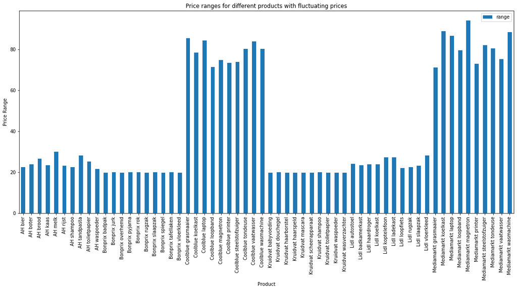

```python
ax = changing_prices.plot(kind = 'bar', x='product', y='range', figsize = (19,8))
ax.set_ylabel('Price Range')
ax.set_xlabel('Product')
ax.set_title('Price ranges for different products with fluctuating prices')
```

One might want to compare the average price ranges recorded for the different websites.

```python
changing_prices["range"].groupby(changing_prices["website_"]).mean()
```

```
website_
AH            24.759
Bonprix       19.907
Coolblue      78.709
Kruidvat      19.864
Lidl          24.602
Mediamarkt    82.030
Name: range, dtype: float64
```

This already gives some indication into the websites most and least likely to be employing algorithmic pricing techologies. However, the collection of items recorded for each website are not the same across websites - for example, CoolBlue's recorded items include a laptop while Kruidvat's recorded items do not. Thus, the comparison between overall average price range for the various websites should be interpreted carefully. It may be more meaningful to compare the average price ranges for the same items across different websites, rather than different items across the same websites.

```python
changing_prices["range"].groupby(changing_prices["item_"]).mean()
```

```
item_
autostoel          24.210000
babyvoeding        19.900000
badkamerkast       23.410000
badpak             19.910000
bier               22.460000
boter              23.880000
brood              26.680000
douchegel          19.950000
grasmaaier         78.395000
haarborstel        19.870000
haardroger         23.840000
haarspeld          19.840000
jurk               19.940000
kaas               23.550000
koelkast           63.813333
koptelefoon        27.410000
ladekast           27.270000
laptop             85.635000
loopband           75.600000
loopfiets          22.140000
magnetron          84.535000
mascara            19.900000
melk               30.130000
overhemd           19.890000
printer            73.275000
pyjama             19.930000
rijst              23.250000
rok                19.960000
rugzak             21.140000
scheerapparaat     19.790000
shampoo            21.220000
slaapzak           21.640000
spiegel            19.870000
steelstofzuiger    77.990000
tafellaken         19.950000
tandpasta          28.290000
toiletpapier       22.540000
tondeuse           80.425000
vaatwasser         79.650000
vloerkleed         23.995000
wasmachine         84.375000
waspoeder          20.725000
wasverzachter      19.770000
Name: range, dtype: float64
```

Here we can see that certain items have large price fluctuations, while other items' prices are far more stable.

It may be suspected that there is a correlation between the price levels of the items and the corresponding price ranges. For example, the more expensive an item, the larger its price range (or vice versa). To determine this, we calculate the correlation between the prices (first maxima and then minima) and the ranges.

```python
x = changing_prices["range"].values
y = changing_prices["price_max"].values
r = np.corrcoef(x, y)
r
```

```
array([[1.        , 0.99989205],
       [0.99989205, 1.        ]])
```

```python
x = changing_prices["range"].values
y = changing_prices["price_min"].values
r = np.corrcoef(x, y)
r
```

```
array([[1.        , 0.74321392],
       [0.74321392, 1.        ]])
```

## 4. Investigation into a specific website

Based on the previous section, or perhaps independently, one might want to investigate one specific website and the fluctuation in prices of items offered by it. To begin, specifiy the website's name. This can be changed at any point and the analysis rerun.

```python
individual_website = dataset.loc[(dataset['website']== 'Coolblue')]
```

We can take a look again at the boxplots to visualize and compare the overall price differences for each item on the website.

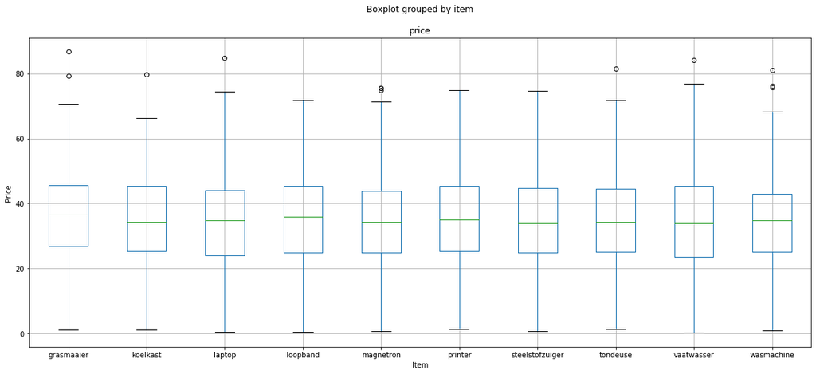

```python
ax = individual_website.boxplot(by = 'item', figsize = (19,8))
ax.set_ylabel('Price')
ax.set_xlabel('Item')
```

\ A meaningful investigation explores how the website's prices for each item changed over time; thus time series plots are included. These can be created for all items individually, or all items can be plotted on one set of axes.

```python
item_array = dataset["item"].unique()
```

```python
web_items = ["0"]* (len(item_array))
for i in range (len(item_array)):
    item_it = individual_website.loc[(individual_website["item"]== item_array[i])]
    web_items[i] = item_it
```

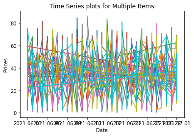

```python
for i in range (len(item_array)):
    plt.plot(web_items[i]["date"],  web_items[i]["price"])
plt.xlabel('Date')
plt.ylabel('Prices')
plt.title('Time Series plots for Multiple Items')
# Change plot size?
```

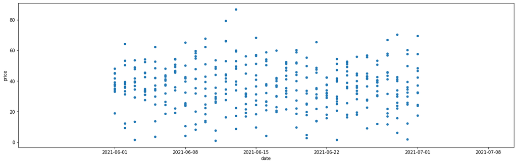

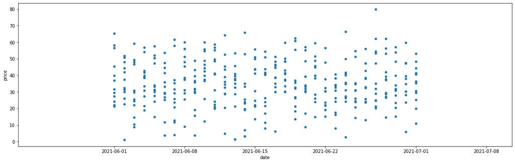

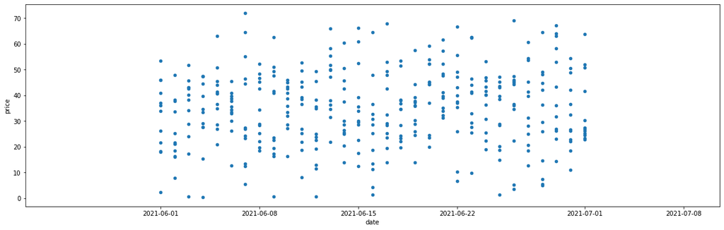

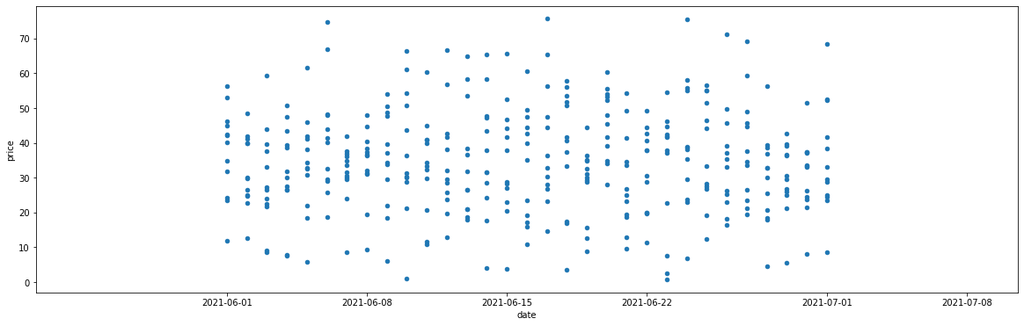

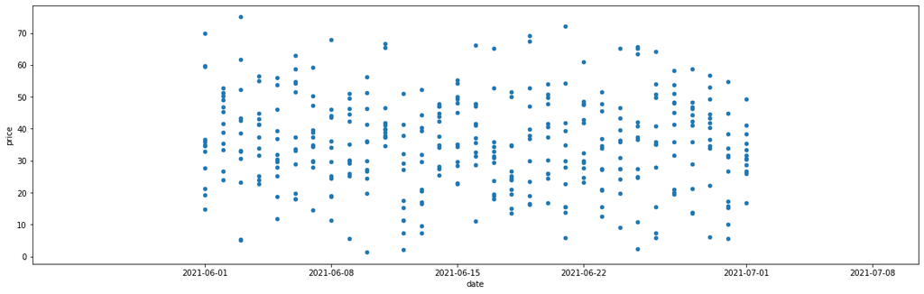

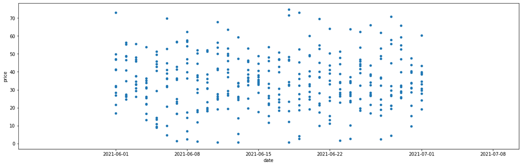

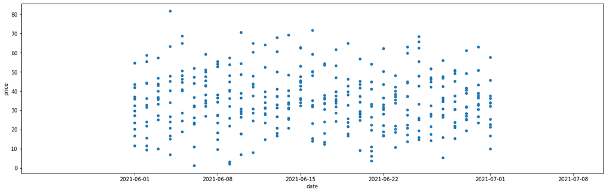

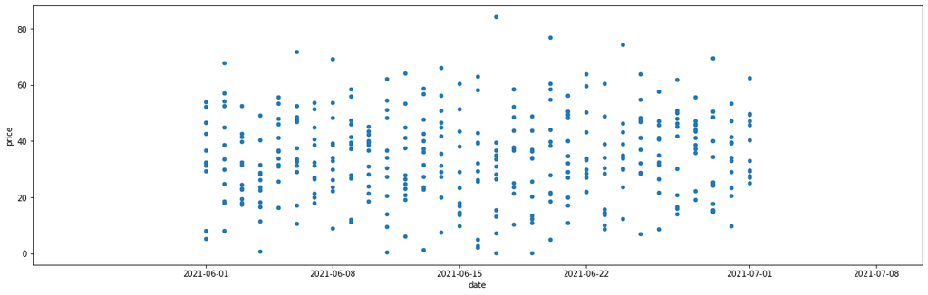

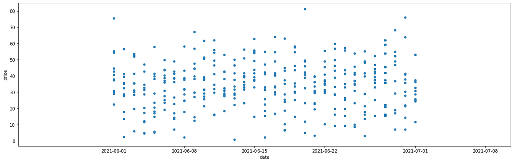

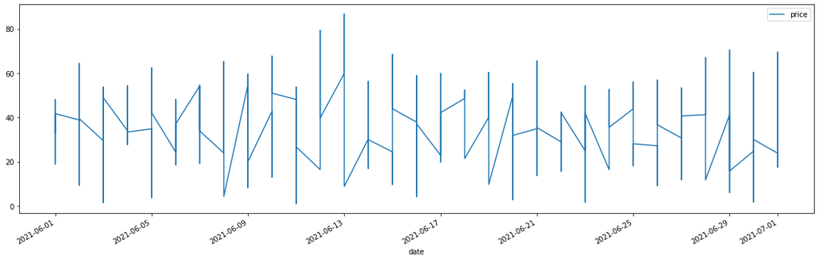

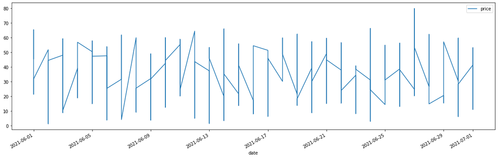

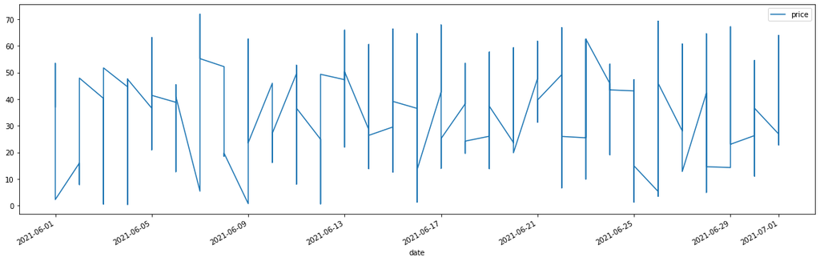

[6 more figures not shown]

```python
ay = individual_website.groupby(individual_website['item']).plot(kind='scatter', x='date', y='price', figsize =(20,6))
# How to set titles to show the items for each scatterplot?

az = individual_website.groupby(individual_website['item']).plot(kind='line', x='date', y='price', figsize =(20,6))
```

## 5. Investigation into a specific item

Certain items appear on different websites, such as a laptop or grasmaaier. It is interesting to explore the level and consistency of the prices of these items across different brands.

Specify the item of interest:

```python
individual_item = dataset.loc[(dataset['item']== 'laptop')]
```

```python
individual_item.describe()
```

|  | price |
| --- | --- |
| count | 744.000000 |
| mean | 34.861237 |
| std | 15.918929 |
| min | 0.360000 |
| 25% | 23.650000 |
| 50% | 34.930000 |
| 75% | 45.095000 |
| max | 88.130000 |

To compare the item's price distributions on different websites, one can consider boxplots, violin plots and side-by-side histograms.

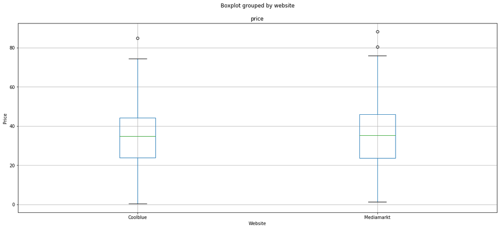

```python
ax = individual_item.boxplot(by = 'website', figsize = (19,8))
ax.set_ylabel('Price')
ax.set_xlabel('Website')
```

```python
web_array = individual_item["website"].unique()

item_webs = ["0"]* (len(web_array))

for i in range (len(web_array)):
    web_it = individual_item.loc[(individual_item["website"]== web_array[i])]
    item_webs[i] = web_it
```

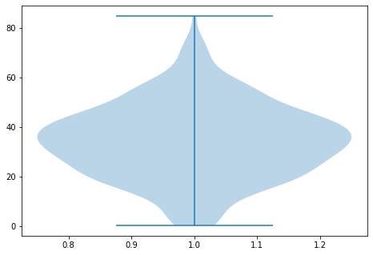

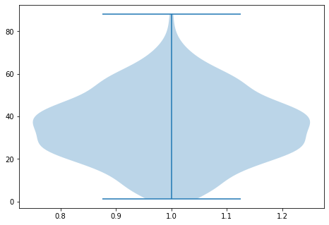

```python
for i in range (len(item_webs)):
    x = item_webs[i]["price"]
    fig = plt.figure()
    ax = fig.add_axes([0,0,1,1])
    bp = ax.violinplot(x)
    plt.show()
```

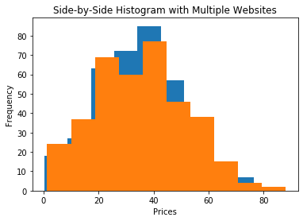

```python
x = ["0"]* (len(item_webs))
for i in range (len(item_webs)):
    x[i] = item_webs[i]["price"]
    plt.hist(x[i])
    plt.xlabel('Prices')
    plt.ylabel('Frequency')
    plt.title('Side-by-Side Histogram with Multiple Websites')

# Hmmmm this should not overlap but rather be side-by-side
```

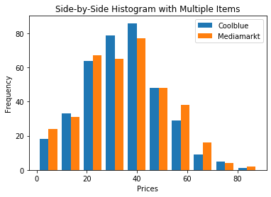

```python
# Want the above to look like this
x1 = list(individual_item[individual_item["website"]== "Coolblue"]["price"])
x2 = list(individual_item[individual_item["website"]== "Mediamarkt"]["price"])
names = ["Coolblue", "Mediamarkt"]
plt.hist([x1, x2], label=names)
plt.legend()
plt.xlabel('Prices')
plt.ylabel('Frequency')
plt.title('Side-by-Side Histogram with Multiple Items')
```

Time series plots are again meaningful to notice trends and patterns over time.

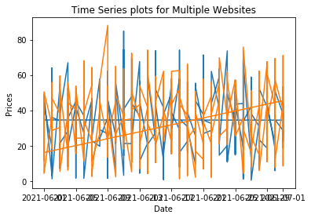

```python
for i in range (len(web_array)):
    plt.plot(item_webs[i]["date"],  item_webs[i]["price"])
plt.xlabel('Date')
plt.ylabel('Prices')
plt.title('Time Series plots for Multiple Websites')
# Change plot size?
```

\ Or if one wants all the time series plots on separate axes:

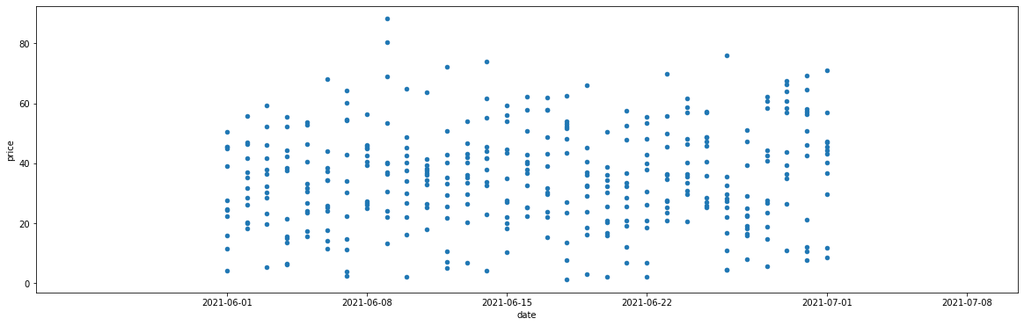

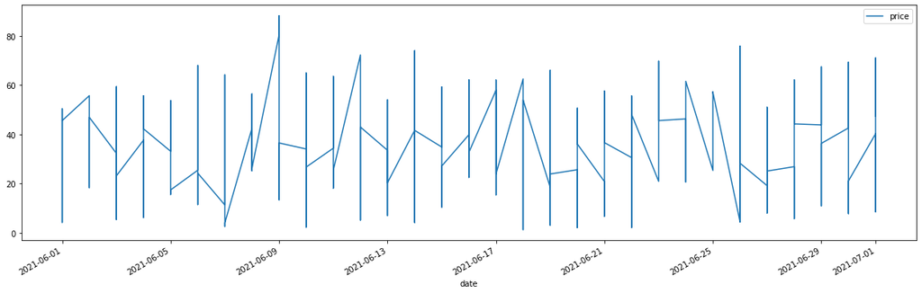

```python
ay = individual_item.groupby(individual_item['website']).plot(kind='scatter', x='date', y='price', figsize =(20,6))

az = individual_item.groupby(individual_item['website']).plot(kind='line', x='date', y='price', figsize =(20,6))
```

Certain items on one website might warrant some individual investigation. To begin we consider a descriptive summary.

```python
dataset['product'] = dataset['website'] + ' ' + dataset['item']
individual_product = dataset.loc[(dataset['product']== 'Coolblue laptop')]
individual_product.describe()
```

|  | price |
| --- | --- |
| count | 372.000000 |
| mean | 34.463925 |
| std | 15.297022 |
| min | 0.360000 |
| 25% | 23.950000 |
| 50% | 34.750000 |
| 75% | 44.147500 |
| max | 84.830000 |

For the product, we calculate the product's average price for each day:

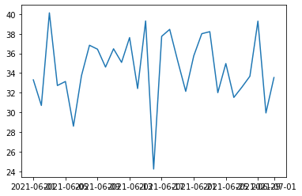

```python
daily_mean = individual_product.groupby(individual_product["date"]).mean()
dates_array = dataset["date"].unique()
plt.plot(dates_array, daily_mean)
```

Then, using the average prices each day, we calculate the **rates of change** from one day to the next, and plot these.

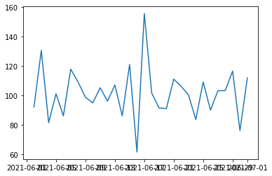

```python
# I think the rates calculation could probably be simplified...
mean = [0]* len(dates_array)
for i in range (len(dates_array)):
    prod_date = individual_product.loc[(individual_product["date"]== dates_array[i])]
    mean[i] = prod_date["price"].mean()
rates = [0]* (len(dates_array)-1)
for i in range (len(dates_array)-1):
    each_rate = mean[i+1]/mean[i]*100
    rates[i] = each_rate
plt.plot(dates_array[1:len(dates_array)],rates)
```

Again we can also consider boxplots, violin plots, histograms and density graphs to understand the price distribution.

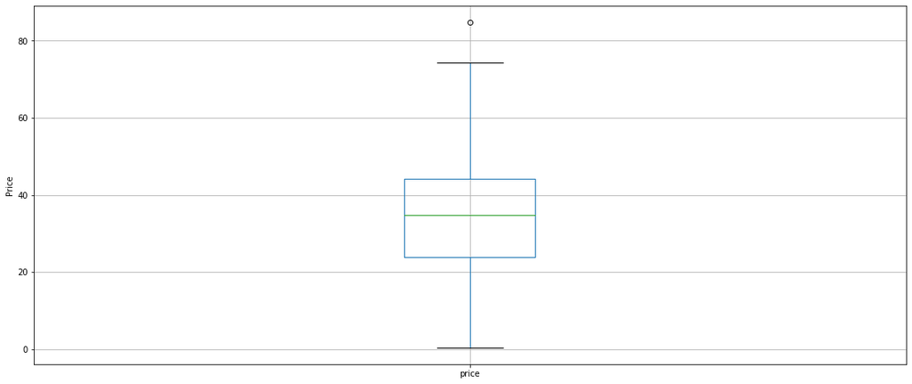

```python
ax = individual_product.boxplot(figsize = (19,8))
ax.set_ylabel('Price')
```

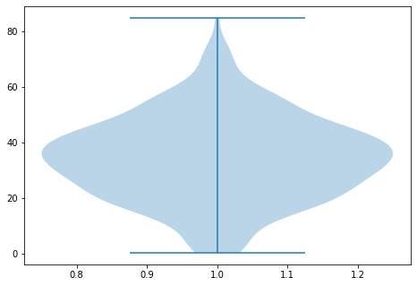

```python
x = individual_product["price"]
data_to_plot = [x]
fig = plt.figure()
ax = fig.add_axes([0,0,1,1])
bp = ax.violinplot(data_to_plot)
plt.show()
```

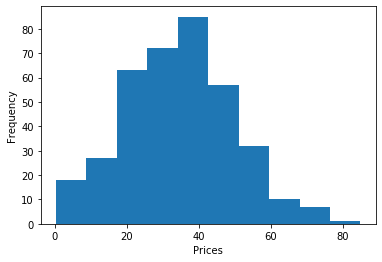

```python
plt.hist(individual_product["price"])
plt.xlabel('Prices')
plt.ylabel('Frequency')
```

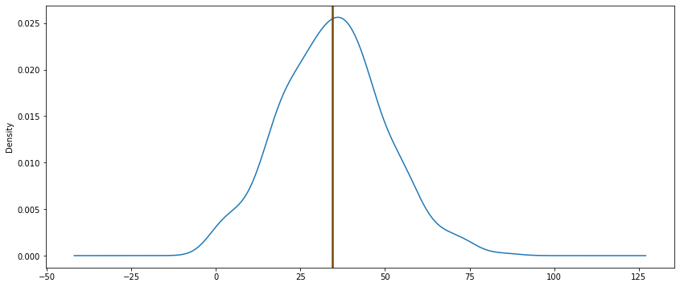

```python
product_mean = individual_product['price'].mean()
product_median = individual_product['price'].median()
ax = individual_product['price'].plot(kind='density', figsize = (14,6))
ax.axvline(product_mean, color = 'red')
ax.axvline(product_median, color = 'green')
```

```python
ay = individual_product.plot(kind='scatter', x='date', y='price', figsize =(20,6))
az = individual_product.plot(kind='line', x='date', y='price', figsize =(20,6))
```

[output not shown]